# Lecture 1

Kodie McNamara

August 30, 2021

## Beginning with R

We can define different computations in different ways, utilizing different **control structures**. Control structures are defined as:  
* for-loops * while-loops * functions * if-else statements * many others…

We can define a factorial function as follows:

```r
Fact <- function(n){
  output = 1
  for(i in 1:n){
    output = output * i
  }
  return(output)
}
```

```r
Fact(5)
```

```
## [1] 120
```

Likewise, there is a factorial function defined in the `base` R package. For functions defined in `base`, we do not need to install or load their libraries. They come with the default R when you installed the program.

```r
factorial(5)
```

```
## [1] 120
```

## Plots, Trends, and Seasonal Variation

### Air Passenger Bookings

There are a handful of datasets that are native to R and we can load in easily utilizing the `data()` function. In particular, we will load in the “Airpassengers” data

```r
data("AirPassengers")
AP = AirPassengers
AP
```

```
##      Jan Feb Mar Apr May Jun Jul Aug Sep Oct Nov Dec
## 1949 112 118 132 129 121 135 148 148 136 119 104 118
## 1950 115 126 141 135 125 149 170 170 158 133 114 140
## 1951 145 150 178 163 172 178 199 199 184 162 146 166
## 1952 171 180 193 181 183 218 230 242 209 191 172 194
## 1953 196 196 236 235 229 243 264 272 237 211 180 201
## 1954 204 188 235 227 234 264 302 293 259 229 203 229
## 1955 242 233 267 269 270 315 364 347 312 274 237 278
## 1956 284 277 317 313 318 374 413 405 355 306 271 306
## 1957 315 301 356 348 355 422 465 467 404 347 305 336
## 1958 340 318 362 348 363 435 491 505 404 359 310 337
## 1959 360 342 406 396 420 472 548 559 463 407 362 405
## 1960 417 391 419 461 472 535 622 606 508 461 390 432
```

We can determine the class of an object by calling the `class` method

```r
class(AP)
```

```
## [1] "ts"
```

Here, we see AP is defined as “ts” for “time series”. We can call a handful of other methods for these types of objects

```r
start(AP)
```

```
## [1] 1949    1
```

```r
end(AP)
```

```
## [1] 1960   12
```

```r
frequency(AP)
```

```
## [1] 12
```

We can also ouput a summary of the dataset

```r
summary(AP)
```

```
##    Min. 1st Qu.  Median    Mean 3rd Qu.    Max.
##   104.0   180.0   265.5   280.3   360.5   622.0
```

There is a generic call for plotting time series (and all other sorts of data) in base R utilizing the `plot()` function. There are a handful of arguments that can go into this function, as well.

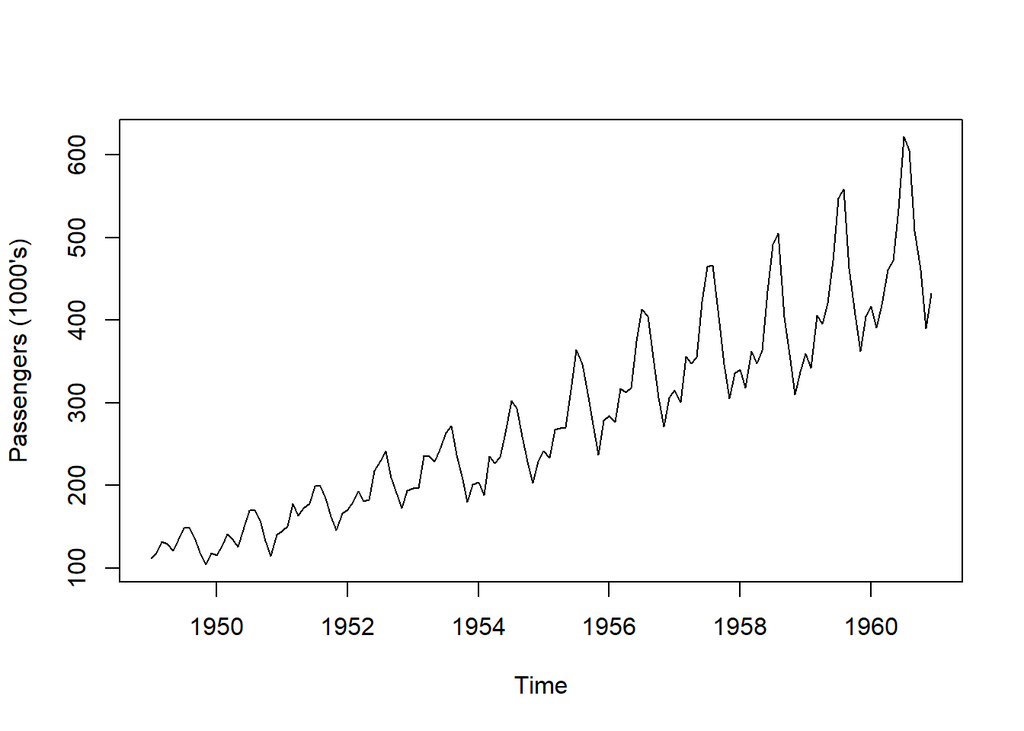

```r
plot(AP, ylab = "Passengers (1000's)")
```

Return to the Lecture 1 Notes for me information on this plot.

We can remove some seasonal variation by aggregating by various time increments. Here, we can call the `agrgegate()` function to aggregate the time series by year, and determine the trend from there.

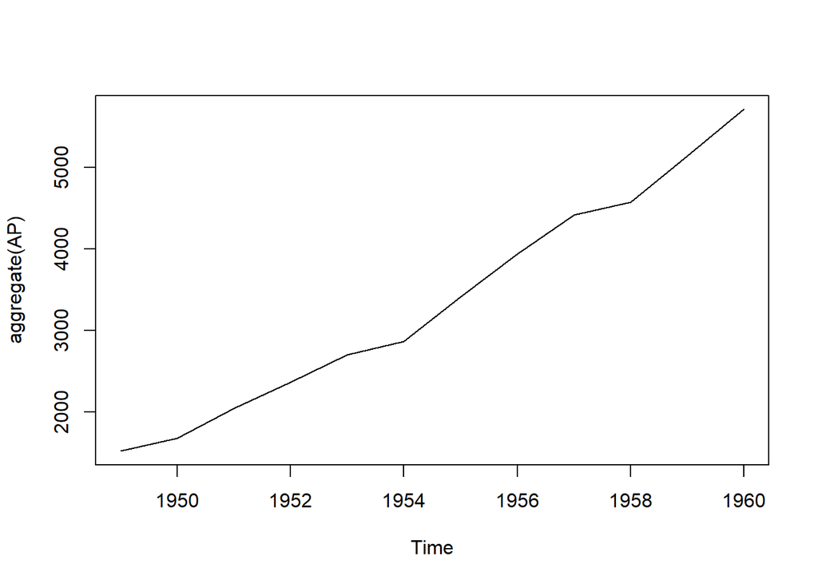

```r
plot(aggregate(AP))
```

Likewise, we can determine each cycle’s characteristics by calling the `cycle()` function and summarising using a boxplot

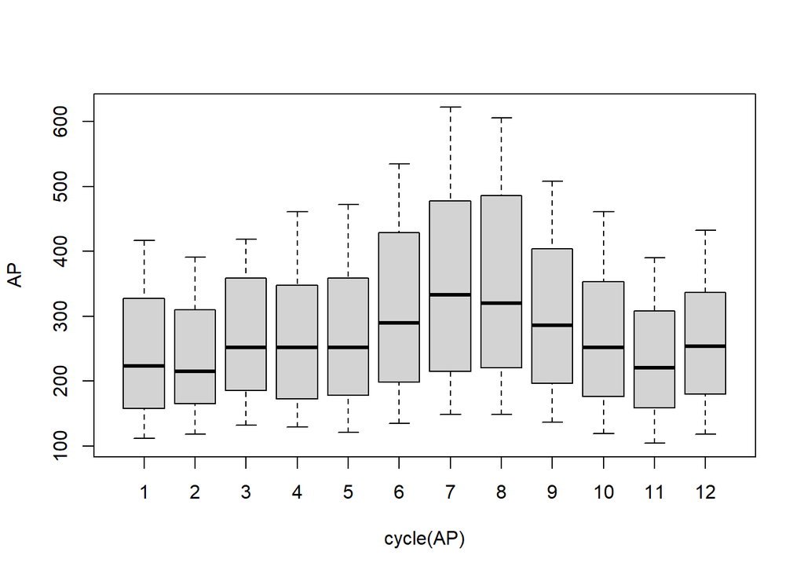

```r
boxplot(AP ~ cycle(AP))
```

### Uneployment: Maine

Monthly unemployment data are available in a file online that is read into R in the code below. We read in the csv from file and manipulate from there

```r
# Set your working directory below if it is not already set to the current 'Lecture Notes' directory.
# Your directory must be set to tell R where to find the data file for Maine monthly unemployment

#setwd()
Maine.month = read.csv(file = "data/Maine.csv")
class(Maine.month)
```

```
## [1] "data.frame"
```

Note this data file is not of type `ts` (time series) but is rather read in as a dataframe. We create a time series object with the following command

```r
Maine.month.ts = ts(Maine.month, start = c(1996, 1), frequency = 12)
```

We can aggregate by year, as well

```r
Maine.annual.ts = aggregate(Maine.month.ts)/12
```

Next, we can plot both time series, both by month and by year.

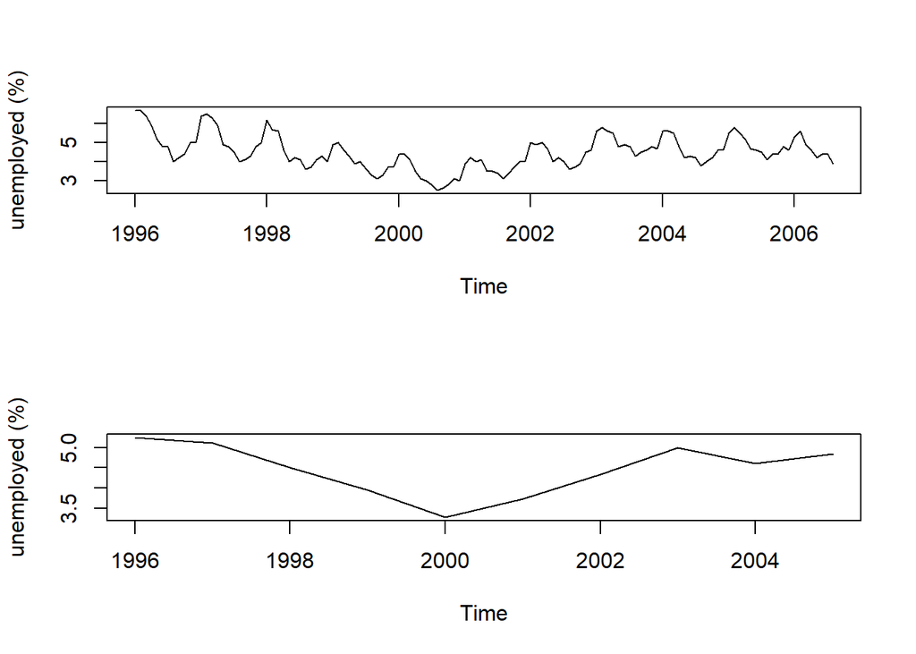

```r
layout(1:2)
plot(Maine.month.ts, ylab = "unemployed (%)")
plot(Maine.annual.ts, ylab = "unemployed (%)")
```

We can compute some of the specific percentages leveraging the `window()` function as described below. We can gain a sense of seasonal variation comparing the months computations to the overall means throughout the year

```r
Maine.Feb <- window(Maine.month.ts, start = c(1996,2), freq = TRUE)
Maine.Aug <- window(Maine.month.ts, start = c(1996,8), freq = TRUE)
Feb.ratio <- mean(Maine.Feb) / mean(Maine.month.ts)
Aug.ratio <- mean(Maine.Aug) / mean(Maine.month.ts)
```

Below, we print those ratios

```r
print(paste0("February Ratio: ", round(Feb.ratio, 4)))
```

```
## [1] "February Ratio: 1.2225"
```

```r
print(paste0("August Ratio: ", round(Aug.ratio, 4)))
```

```
## [1] "August Ratio: 0.8164"
```

### Global Temperatures

Below we read in the global temperatures file and build the time-series object for both the complete set of data points and aggregated on the annual basis. We need to manipulate the data a bit, too, because each row is a year and each column is the month. Thus, we aggregate the data into one column.

```r
# Set your working directory below if it is not already set to the current 'Lecture Notes' directory.
# Your directory must be set to tell R where to find the data file for Maine monthly unemployment

#setwd()
Global_file = read.csv(file = "data/Global.csv", header = F)

Global = data.frame()
for(row in 1:nrow(Global_file)){
  for(column in 1:ncol(Global_file)){
    Global = rbind.data.frame(Global, Global_file[row,column])
  }
}

names(Global) = "Temperate in C"
```

Next, we plot both all the data points and the yearly aggregate

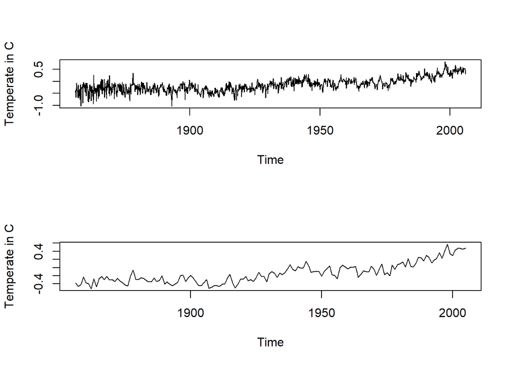

```r
Global.ts <- ts(Global, st = c(1856, 1), end = c(2005, 12), fr = 12)
Global.annual <- aggregate(Global.ts, FUN = mean)
layout(1:2)
plot(Global.ts)
plot(Global.annual)
```

Next, we can narrow down our time series from 1970 onward and get a sense of a more recent trend. Here, we can create a line of best fit using `abline()`

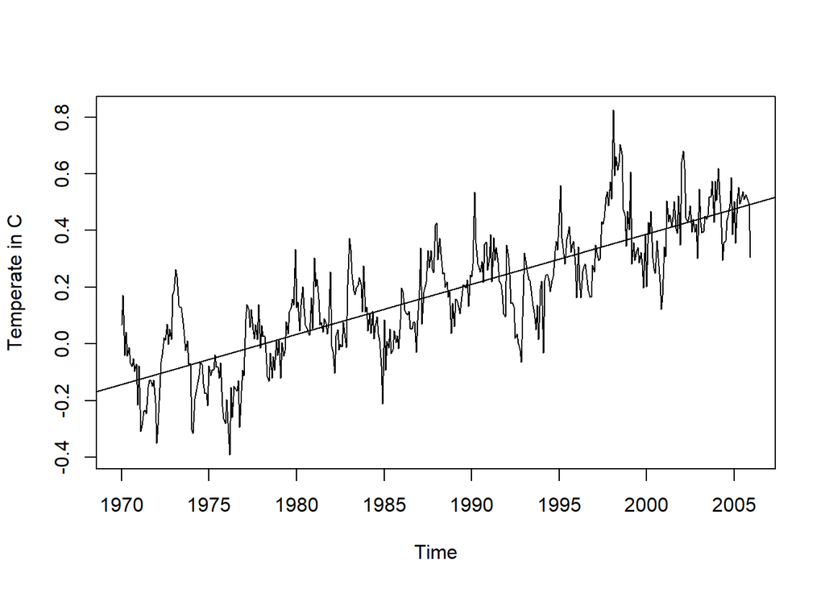

```r
New.series <- window(Global.ts, start=c(1970, 1), end=c(2005, 12))
New.time <- time(New.series)
plot(New.series)
abline(reg=lm(New.series ~ New.time))
```

## Decomposition in R

In R, the function `decompose()` estimates trends and seasonal effects using a moving average method. Nesting the function within plot (e.g., using `plot(stl())`) produces a single figure showing the original series $x_{t}$ and the decomposed series $m_{t}$, $s_{t}$, and $z_{t}$.

We read in a new data set, electricity

```r
# Set your working directory below if it is not already set to the current 'Lecture Notes' directory.
# Your directory must be set to tell R where to find the data file for Maine monthly unemployment

#setwd()
Elec = read.csv("data/elec.csv")
Elec.ts <- ts(Elec, start = 1958, freq = 12)
```

Next, we visualize its additive decomposition

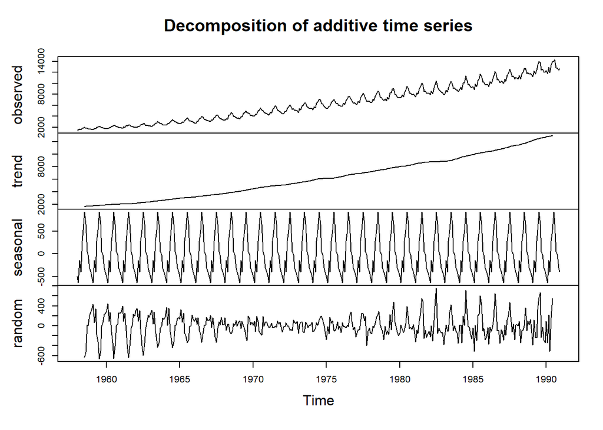

```r
plot(decompose(Elec.ts))
```

Next, its multiplicative decomposition

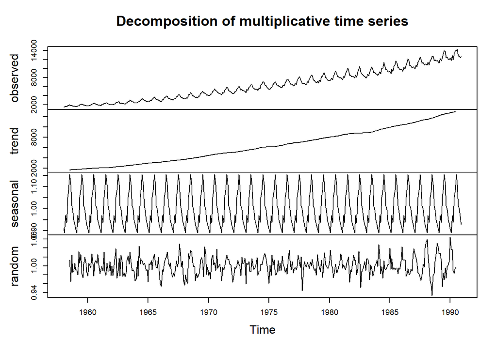

```r
Elec.decom <- decompose(Elec.ts, type = "mult")
plot(Elec.decom)
```

Finally, the trend multiplied by the seasonal, which does not account for randon noise

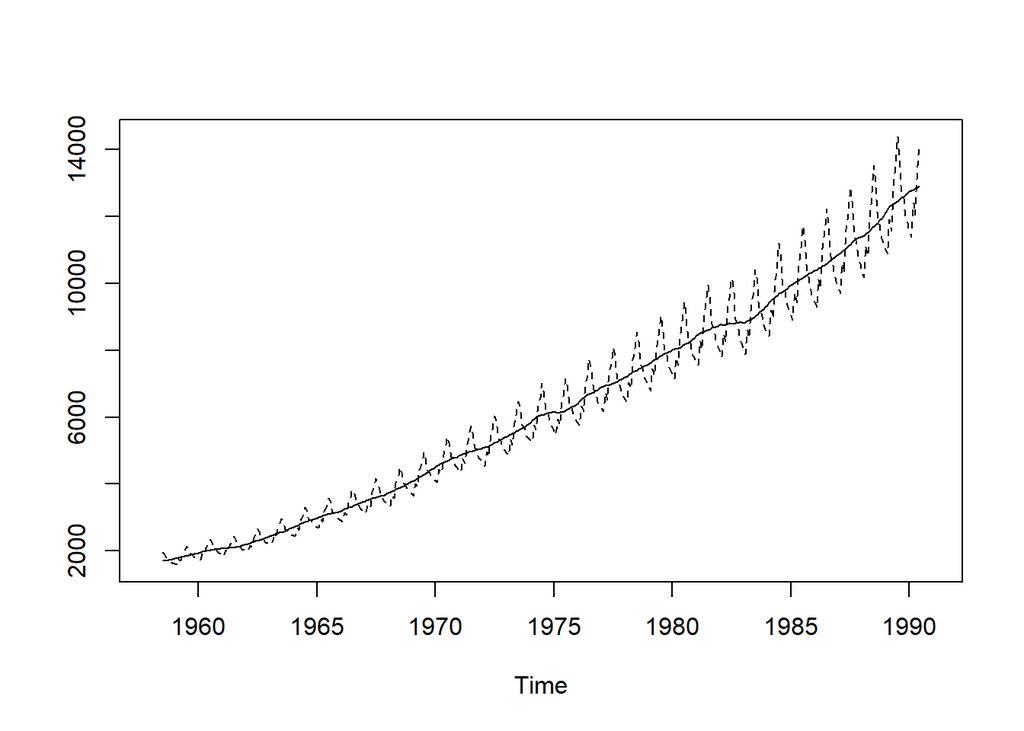

```r
Trend <- Elec.decom$trend
Seasonal <- Elec.decom$seasonal
ts.plot(cbind(Trend, Trend * Seasonal), lty = 1:2)
```